# Capstone Project

Jeevithiesh Duggani

11/05/2020

## Import the necessary libraries

Import the following libraries.

- stringi
- tm
- ggplot2

```r
    library(stringi)
    library(tm)
    library(RWeka)
    library(SnowballC)
    library(ggplot2)
```

## Import the Data into the Environment

### Download the Dataset

This project uses the `dataset` provided by the **Data Science Specialization Course** on Coursera. The dataset can be accessed from [Capstone Dataset](https://d396qusza40orc.cloudfront.net/dsscapstone/dataset/Coursera-SwiftKey.zip).

Download and Extract the `dataset` if it is not already present C:/Users/Jeevithiesh/Desktop/Learning/Coursera/Data Science Specialization/Capstone Project.

```r
    url     <- "http://d396qusza40orc.cloudfront.net/dsscapstone/dataset/Coursera-SwiftKey.zip"
    zipFile <- "Coursera-SwiftKey.zip"
    dFolder <- "final"
    if(!(file.exists(zipFile) | file.exists(dFolder))) download.file(url, zipFile)
    if(!file.exists(dFolder)) unzip(zipFile)
    if(file.exists(zipFile)) file.remove(zipFile)
```

### Understanding the data of the file

Size of `en_US.blogs.txt`.

```bash
    ls -alh "final/en_US/en_US.blogs.txt"
```

```
## -rwxrwxrwx 1 jeevithiesh jeevithiesh 201M May 11 10:15 final/en_US/en_US.blogs.txt
```

Number of lines in `en_US.twitter.txt`.

```bash
    wc -l "final/en_US/en_US.twitter.txt"
```

```
## 2360148 final/en_US/en_US.twitter.txt
```

Longest of lines in `en_US`.

```bash
    wc -L "final/en_US/en_US.blogs.txt" "final/en_US/en_US.news.txt" "final/en_US/en_US.twitter.txt"
```

```
##     40833 final/en_US/en_US.blogs.txt
##     11384 final/en_US/en_US.news.txt
##       173 final/en_US/en_US.twitter.txt
##     40833 total
```

```bash
    ls
```

```
## Capstone Project.Rmd
## Capstone Project.Rproj
## Capstone-Project.Rmd
## LICENSE
## README.md
## final
```

### Import the data from the dataset

The datasets consists of data collecteed from **three** different sources in **four** countries. Store the data in individual `data frames` seperated by **source** and **countries**.

```r
    ##  Datasets sourced from blogs
    DEBlogData <- readLines("final/de_DE/de_DE.blogs.txt", encoding = "UTF-8", skipNul = TRUE)
    USBlogData <- readLines("final/en_US/en_US.blogs.txt", encoding = "UTF-8", skipNul = TRUE)
    FIBlogData <- readLines("final/fi_FI/fi_FI.blogs.txt", encoding = "UTF-8", skipNul = TRUE)
    RUBlogData <- readLines("final/ru_RU/ru_RU.blogs.txt", encoding = "UTF-8", skipNul = TRUE)
    ##  Datasets sourced from News
    DENewsData <- readLines("final/de_DE/de_DE.news.txt", encoding = "UTF-8", skipNul = TRUE)
    USNewsData <- readLines("final/en_US/en_US.news.txt", encoding = "UTF-8", skipNul = TRUE)
    FINewsData <- readLines("final/fi_FI/fi_FI.news.txt", encoding = "UTF-8", skipNul = TRUE)
    RUNewsData <- readLines("final/ru_RU/ru_RU.news.txt", encoding = "UTF-8", skipNul = TRUE)
    ##  Datasets sourced from blogs
    DETwitterData <- readLines("final/de_DE/de_DE.twitter.txt", encoding = "UTF-8", skipNul = TRUE)
    USTwitterData <- readLines("final/en_US/en_US.twitter.txt", encoding = "UTF-8", skipNul = TRUE)
    FITwitterData <- readLines("final/fi_FI/fi_FI.twitter.txt", encoding = "UTF-8", skipNul = TRUE)
    RUTwitterData <- readLines("final/ru_RU/ru_RU.twitter.txt", encoding = "UTF-8", skipNul = TRUE)
```

## Identifying the Data

Identify the number of lines and words

```r
    length(DEBlogData);length(USBlogData);length(FIBlogData);length(RUBlogData)
```

```
## [1] 181958
```

```
## [1] 899288
```

```
## [1] 439785
```

```
## [1] 337100
```

```r
    length(DENewsData);length(USNewsData);length(FINewsData);length(RUNewsData)
```

```
## [1] 244743
```

```
## [1] 77259
```

```
## [1] 485758
```

```
## [1] 196360
```

```r
    length(DETwitterData);length(USTwitterData);length(FITwitterData);length(RUTwitterData)
```

```
## [1] 947774
```

```
## [1] 2360148
```

```
## [1] 285214
```

```
## [1] 881414
```

- There are 181958, 244743, 947774 lines in Blog, News and Twitter datasets in German
- There are 899288, 77259, 2360148 lines in Blog, News and Twitter datasets in English, US.
- There are 439785, 485758, 285214 lines in Blog, News and Twitter datasets in Finnish
- There are 337100, 196360, 881414 lines in Blog, News and Twitter datasets in Russian

```r
    sum(stri_count_words(DEBlogData));
```

```
## [1] 6205913
```

```r
    sum(stri_count_words(USBlogData));
```

```
## [1] 37546239
```

```r
    sum(stri_count_words(FIBlogData));
```

```
## [1] 12785318
```

```r
    sum(stri_count_words(RUBlogData))
```

```
## [1] 9388482
```

```r
    sum(stri_count_words(DENewsData));
```

```
## [1] 13375092
```

```r
    sum(stri_count_words(USNewsData));
```

```
## [1] 2674536
```

```r
    sum(stri_count_words(FINewsData));
```

```
## [1] 10532432
```

```r
    sum(stri_count_words(RUNewsData))
```

```
## [1] 9057248
```

```r
    sum(stri_count_words(DETwitterData));
```

```
## [1] 11646047
```

```r
    sum(stri_count_words(USTwitterData));
```

```
## [1] 30093413
```

```r
    sum(stri_count_words(FITwitterData));
```

```
## [1] 3147077
```

```r
    sum(stri_count_words(RUTwitterData))
```

```
## [1] 9231336
```

- There are 6205913, 13375092, 11646047 words in Blog, News and Twitter datasets in German
- There are 37546239, 2674536, 30093413 words in Blog, News and Twitter datasets in English, US.
- There are 12785318, 10532432, 3147077 words in Blog, News and Twitter datasets in Finnish
- There are 9388482, 9057248, 9231336 words in Blog, News and Twitter datasets in Russian

## Cleaning the Data

Remove URLs, punctuations, special characters, excess whitespace, stopwords and different cases. The following part of the assignment will be only for the data in the US Database. The preprocessing steps will be demonstrated on `1%` of the data provided.

```r
    set.seed(2020)

    USBlogSample <- sample(USBlogData, length(USBlogData) * 0.01)
    USNewsSample <- sample(USNewsData, length(USNewsData) * 0.01)
    USTwitterSample <- sample(USTwitterData, length(USTwitterData) * 0.01)

    USBlogSample    <- iconv(USBlogSample,    "latin1", "ASCII", sub="")
    USNewsSample    <- iconv(USNewsSample,    "latin1", "ASCII", sub="")
    USTwitterSample <- iconv(USTwitterSample, "latin1", "ASCII", sub="")

    sampleData <- c(USBlogSample, USNewsSample, USTwitterSample)
```

```r
    Textprocessing <- function(x){
        gsub("http[[:alnum:]]*",'', x)
        gsub('http\\S+\\s*', '', x) ## Remove URLs
        gsub('\\b+RT', '', x) ## Remove RT
        gsub('#\\S+', '', x) ## Remove Hashtags
        gsub('@\\S+', '', x) ## Remove Mentions
        gsub('[[:cntrl:]]', '', x) ## Remove Controls and special characters
        gsub("\\d", '', x) ## Remove Controls and special characters
        gsub('[[:punct:]]', '', x) ## Remove Punctuations
        gsub("^[[:space:]]*","",x) ## Remove leading whitespaces
        gsub("[[:space:]]*$","",x) ## Remove trailing whitespaces
        gsub(' +',' ',x) ## Remove extra whitespaces
    }
```

```r
    corpus <- Corpus(VectorSource(sampleData))

    corpus <- tm_map(corpus, Textprocessing)
    corpus <- tm_map(corpus, tolower)
    corpus <- tm_map(corpus, removeNumbers)
    corpus <- tm_map(corpus, removePunctuation)
    corpus <- tm_map(corpus, removeWords, stopwords("en"))
    corpus <- tm_map(corpus, stripWhitespace)

    corpus <- VCorpus(VectorSource(corpus), readerControl=list(reader=readPlain, language="en"))
```

## Graphical Analysis

Plot the frequency histograms of the unigrams.

```r
    freq_table <- function(nCorpus){
        freq <- sort(rowSums(as.matrix(nCorpus)), decreasing = TRUE)
        freq_table <- data.frame(nGram = names(freq), freq = freq)
        return(freq_table)
    }
```

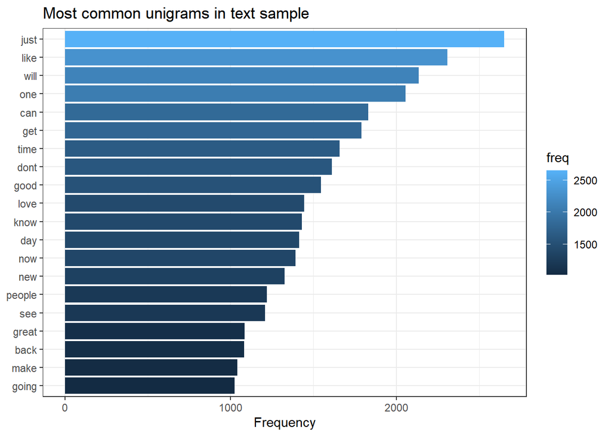

```r
    uniCorpus <- TermDocumentMatrix(corpus)
    uniCorpus <- removeSparseTerms(uniCorpus, 0.99)
    unigrams  <- freq_table(uniCorpus)
    plotData  <- head(unigrams, 20)

    plot <- ggplot(plotData, aes(x = reorder(nGram, freq), y = freq, fill = freq))
    plot <- plot + geom_bar(stat="identity")
    plot <- plot + theme_bw() + coord_flip() + theme(axis.title.y = element_blank())
    plot <- plot + labs(y="Frequency", title="Most common unigrams in text sample")
    plot
```

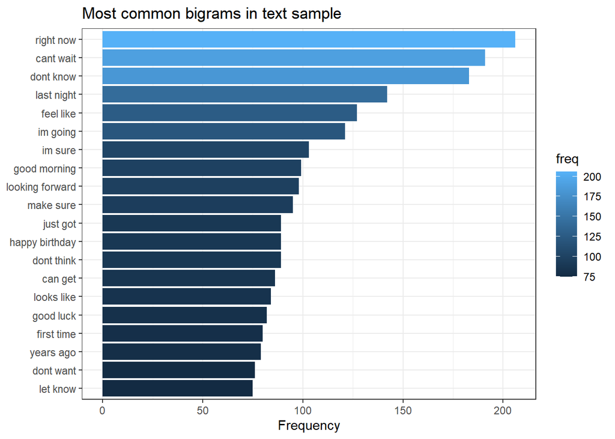

```r
    bigramTokenizer <- function(x) NGramTokenizer(x, Weka_control(min = 2, max = 2))
    biCorpus <- TermDocumentMatrix(corpus, control = list(tokenize = bigramTokenizer))
    biCorpus <- removeSparseTerms(biCorpus, 0.999)
    bigrams  <- freq_table(biCorpus)
    plotData  <- head(bigrams, 20)

    plot <- ggplot(plotData, aes(x = reorder(nGram, freq), y = freq, fill = freq))
    plot <- plot + geom_bar(stat="identity")
    plot <- plot + theme_bw() + coord_flip() + theme(axis.title.y = element_blank())
    plot <- plot + labs(y="Frequency", title="Most common bigrams in text sample")
    plot
```

[figure not shown]

```r
    trigramTokenizer <- function(x) NGramTokenizer(x, Weka_control(min = 3, max = 3))
    triCorpus <- TermDocumentMatrix(corpus, control = list(tokenize = trigramTokenizer))
    triCorpus <- removeSparseTerms(triCorpus, 0.9999)
    trigrams  <- freq_table(triCorpus)
    plotData  <- head(trigrams, 20)

    plot <- ggplot(plotData, aes(x = reorder(nGram, freq), y = freq, fill = freq))
    plot <- plot + geom_bar(stat="identity")
    plot <- plot + theme_bw() + coord_flip() + theme(axis.title.y = element_blank())
    plot <- plot + labs(y="Frequency", title="Most common bigrams in text sample")
    plot
```

## Next Steps

The next step is to create a *model* and integrate it into a **Shiny app** for word prediction.

### Model

- Use the Ngram dataframes created to calculate the probabilities of the next word.
- Tokenize the input string
- Cross Check the `quadgrams`, `trigrams`, `bigrams` and `unigrams` in the end of the input string with the Ngram dataframes in order to identify the next word.

### Shiny App

- Integrate the model framework created above into a shiny application.
- Generate the Shiny App.